# Introducción a librerías de DataScience en Python: Xarray y datos CMEMS

# Objetivos

- Aprender a crear entornos virtuales con conda.
- Acceder a los datos de CMEMS vía OpeNDAP utilizando la librería de python Pydap
- Aprender a trabajar con ellos sin la necesidad de descargarlos utilizando la librería xarray

¿Que necesitamos para ejecutar los códigos?

- Anaconda
- Entorno virtual
- Jupyter Notebook

# Anaconda

[Anaconda](https://www.anaconda.com/products/distribution) es una **distribución de lenguajes de programación** Python y R ampliamente utilizada en computación científica, en particular en ciencias de dato, aplicaciones de machine learning, etc.

Ventajas:

- es software libre
- simplifica la gestión de librerías y entornos

Incluye:

- El administrador de paquetes **conda**
- **Anaconda Navigator**, una interface gráfica de usuario (GUI) que permite el fácil acceso a las siguientes aplicaciones:
  - `JupyterLab`
  - `Jupyter Notebooks`
  - Spyder (entorno de desarrollo para python)
  - IBM Watson
  - Datalore
  - Qt console
  - PyCharm
  - Glueviz
  - Orange 3
  - RStudio (entorno de desarrollo para R)

[Miniconda](https://docs.conda.io/en/latest/miniconda.html) es una versión minimalista de Anaconda que solo incluye conda y python y no posee la interface gráfica.

[figure not shown]

# Entornos virtuales

**¿Qué son los entornos virtuales?**

Los entornos virtuales son **espacios independientes** de la instalación local de python que **aísla los recursos y librerías necesarias** para ejecutar los códigos del proyecto. Esto nos permite tener diferentes entornos con diferentes librerías e incluso diferentes versiones de python.

**¿Cuándo son útiles?**

Cuando se trabaja en un proyecto de python en **colaboración** con otras personas o cuando se quiere volver a ejecutar un **proyecto antiguo**, muchas veces se necesita tener instaladas versiones específicas, no solo de las librerías utilizadas sino de también del propio runtime de Python. Por este motivo, **trabajar en un solo entorno** de Python o conda **es complicado** y puede generar problemas.

## Crear un entorno virtual con conda

1. Instalar la distribución de lenguajes [Anaconda](https://www.anaconda.com/) que incluye el gestor de paquetes conda, o [Miniconda](https://docs.conda.io/en/latest/miniconda.html) (un instalador mínimo de conda).
1. Abrir el prompt y dirigirse al directorio de trabajo.
1. Crear un nuevo entorno: `conda create -n nombre_entorno python`
1. Activar el entorno: `conda activate nombre_entorno`

Una vez que el entorno está activado, su nombre debe aparecer en la terminal:

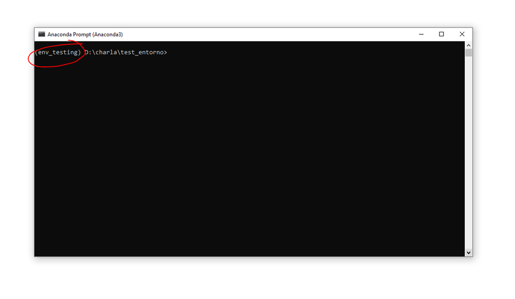

1. En el entrono recién creado, instalar las librerías necesarias, por ejemplo, Jupyter notebook para ejecutar este notebook:

   `conda install -c anaconda jupyter`

   `conda install -c anaconda xarray`

   `conda install -c conda-forge pydap`
1. Checkear qué librerías se encuentran instaladas: `conda list -e`
1. Exportar el entorno en formato yml (de esta forma se puede compartir).

   `conda env export > nombre_archivo.yml`

Para eliminar el entorno:

`conda deactivate`

y luego:

`conda remove --name nombreentorno --all`

## Activar/desactivar un entorno virtual

Para activar un entorno virtual ya creado y exportado en formato yml o yaml, primero debemos crear el entorno virtual a partir del archivo que lo contiene, para esto es necesario abrir el Anaconda prompt, ir a la carpeta donde esta el archivo yml y escribir:

`conda env create -f nombre_archivo.yml`

Una vez creado el entorno, ya sea mediante el archivo yml, o bien creado desde cero como en el apartado anterior, lo podemos activar escribiendo:

`conda activate nombre_entorno`

Para desactivarlo escribimos:

`conda deactivate`

*Comentario*: en el caso de desarrollar una aplicación que deba ser desplegada en Ansible, es mejor trabajar con linux utilizando [wsl](https://learn.microsoft.com/es-es/windows/wsl/install) (subsistema de windows para linux) y utilizar pip y venv en lugar de conda para crear el entorno e instalar las librerías.

# Jupyter Notebooks

[Jupiter Notebook](https://jupyter.org/) es una aplicación web que permite crear y compartir documentos científicos computacionales, en los cuales se pueden incluir texto, ecuaciones, imágenes, y ejecutar código. Los notebooks permiten presentar y compartir resultados de una forma muy clara y práctica, a la vez que realizar presentaciones, webs, etc.

En este curso utilizamos jupyter notebook en nuestro entorno de trabajo, para esto hay que seguir los siguientes pasos:

1. Abrir el prompt de Anaconda y dirigirse al directorio en donde se va a trabajar.
2. Activar el entorno virtual de trabajo siguiendo los pasos del apartado anterior.
3. Instalar jupyter notebook (en caso de que no se haya hecho ya): `conda install -c anaconda jupyter`
4. Escribir en la consola: `jupyter notebook`
5. Esto abrirá un explorador con el contenido del directorio:

[figure not shown]

Para crear un nuevo notebook, simplemente clickear en "New", "Python3"

[figure not shown]

# Acceso a los datos

## OPeNDAP y Copernicus

[figure not shown]

[OPeNDAP](https://www.opendap.org/) "Open-source Project for a Network Data Access Protocol"

- *Protocolo de acceso a datos científicos* almacenados en un servidor remoto que permite trabajar con ellos sin la necesidad de descargarlos.
- Es uno de los principales endpoints de *acceso* proporcionados por *Copernicus* a sus usuarios.
- Se encuentra especialmente *adecuado* (aunque no estrictamente limitado) a *datos en formato netCDF*.

Descargar los datos de algunos productos de Copernicus, como por ejemplo los últimos años del producto [Global Ocean Wave](https://data.marine.copernicus.eu/product/GLOBAL_ANALYSISFORECAST_WAV_001_027/description) puede tomar horas. Sin embargo gracias a OPeNDAP podemos seleccionar un subconjunto de datos o las variables que necesitemos y trabajar con ellas en pocos segundos sin la necesidad de descargar todos los datos.

También se puede utilizar este protocolo para acceder a *Thredds*.

# Librerías y herramientas

A continuación describiremos las librerías y principales herramientas que utilizaremos para el acceso y análisis de los datos:

[Pydap](https://www.pydap.org/en/latest/) Es una librería de Python que implementa el protocolo de acceso a OPeNDAP.

[netCDF](https://www.unidata.ucar.edu/software/netcdf/) Es un formato de datos orientado a almacenar, compartir y acceder a datos científicos multidimensionales y además incluye atributos que permiten describir y entender los datos. Existen librerías orientadas a trabajar con estos datos en diversos lenguajes de programación, una de ellas es xarray en python.

[xarray](https://docs.xarray.dev/en/stable/) es una librería de Python que permite trabajar con arreglos de datos multidimensionales en formato nedcdf. Entre otras cosas, xarray permite:

- introducir etiquetas en forma de dimensiones, coordenadas y atributos sobre arrays tipo NumPy.
- aplicar una serie de operaciones matemáticas sobre los datos.
- seleccionar variables por nombre.
- dividir o reagrupar datos
- el análisis de datos en remoto vía OpenDAP

La librería xarray almacena los datos en objetos de clase data sets y data arrays que poseen un formato compatible con netCDF.

Data set:

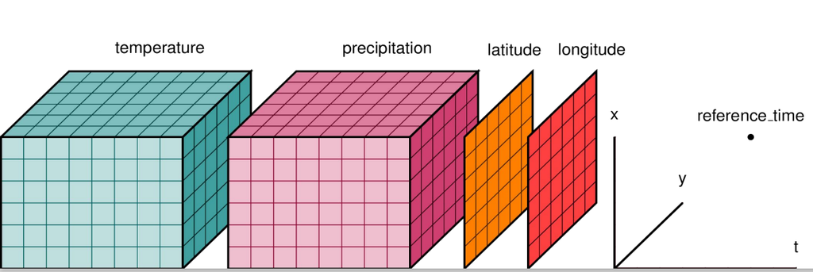

[Numpy](https://numpy.org/) Es una librería de python especializada en cálculo numérico y el análisis de datos que incorpora una clase de objetos llamados arrays sobre los cuales se pueden procesar cálculos unas 50 veces más rápido que utilizando las listas predefinidas de python.

[Pandas](https://pandas.pydata.org/) Es una librería de python para manipulación y análisis de datos en forma de tabla por medio de etiquetas e índices.

A continuación importamos todas la librerías que vamos a utilizar `xarray`, `pydap`, `numpy`, `pandas`,`datetime`

```python
import xarray as xr
from pydap.cas.get_cookies import setup_session
from pydap.client import open_url
from datetime import datetime
import numpy as np
import pandas as pd
import matplotlib.pyplot as plt
```

# Acceder a los datos

Primero nos conectaremos a [CMEMS](https://marine.copernicus.eu/es) y accederemos a ciertos [datos](https://data.marine.copernicus.eu/product/IBI_MULTIYEAR_WAV_005_006/description). Para esto, necesitamos un perfil en CMEMS con nombre de usuario y password y el link de acceso a los datos,

```python
url = "https://my.cmems-du.eu/thredds/dodsC/cmems_mod_ibi_wav_my_0.05deg-2D_PT1H-i"
username = "***"
password = "***"
```

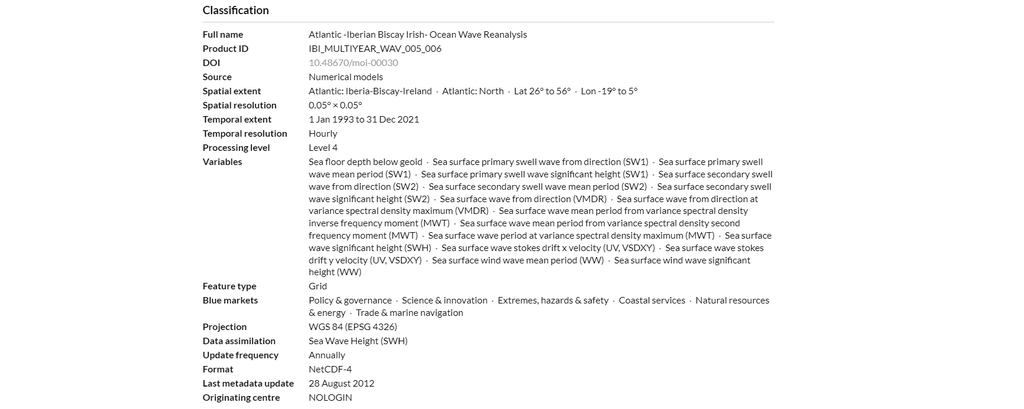

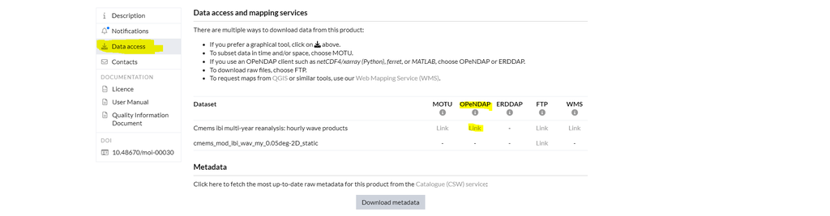

Una vez creado el perfil, podemos acceder a los datos, para esto utilizamos la función `setup_session` de `pydap` para iniciar sesión con nuestro nombre de usuario y password y luego accedemos a los datos en formato nedcf con la función `PydapDataStore` de xarray. Por último, abrimos el dataset con `open_dataset`.

```python
print('Iniciando sesión')
cas_url = "https://cmems-cas.cls.fr/cas/login"
session = setup_session(cas_url, username, password)
session.cookies.set("CASTGC", session.cookies.get_dict()["CASTGC"])
#needed to keep the session alive, CAS: Central Authentication Service, TGC:Long Term Authentication

print('Accediendo a los datos')
data_store = xr.backends.PydapDataStore(open_url(url, session=session))
ds = xr.open_dataset(data_store)
```

```
Iniciando sesión
Accediendo a los datos
```

El data set contiene coordenadas (latitud, longitud y tiempo), múltiples arrays multidimensionales (variables), etiquetas y atributos.

```python
#dataset
ds
```

ds contiene una matriz con 601*481 puntos, y 254184 pasos temporales horarios.

Podemos hacer lo mismo con un producto de Thredds:

```python
dataset = xr.open_dataset('https://ihthredds.ihcantabria.com/thredds/dodsC/IBI_ANALYSIS_FORECAST_WAV_005_005/IBI/hourly/IBI_2023012300.nc')
dataset
```

# Explorando los datos con xarray

Podemos obtener información de las coordenadas del data set ds:

```python
#Obtener información de las coordenadas
ds.coords
```

Y de las variables:

```python
#Obtener información de las variables
ds.variables
```

## Seleccionando y graficando los datos

Seleccionamos la primera variable: [Spectral significant wave height (Hm0)](https://en.wikipedia.org/wiki/Significant_wave_height)

```python
VHM0 = ds.VHM0
```

También podemos seleccionar de otras maneras:

```python
#otras formas de seleccionar variables
#VHM0 = ds.get("VHM0")
#VHM0 = ds['VHM0']
```

Observación: VHM0 es un DataArray, mientras que ds es un DataSet. Veamos que hay dentro de VHM0...

```python
VHM0
```

```
<xarray.DataArray 'VHM0' (time: 254184, latitude: 601, longitude: 481)>
[73479764904 values with dtype=float32]
Coordinates:
  * latitude   (latitude) float32 26.0 26.05 26.1 26.15 ... 55.9 55.95 56.0
  * longitude  (longitude) float32 -19.0 -18.95 -18.9 -18.85 ... 4.9 4.95 5.0
  * time       (time) datetime64[ns] 1993-01-01 ... 2021-12-30T23:00:00
Attributes:
    units:             m
    standard_name:     sea_surface_wave_significant_height
    long_name:         Spectral significant wave height (Hm0)
    type_of_analysis:  spectral analysis
    WMO_code:          100
    valid_min:         0
    valid_max:         3000
    _ChunkSizes:       [12, 301, 241]
```

De manera similar podemos seleccionar las coordenadas:

```python
#accedemos a las latitudes
VHM0.latitude
```

```
<xarray.DataArray 'latitude' (latitude: 601)>
array([26.  , 26.05, 26.1 , ..., 55.9 , 55.95, 56.  ], dtype=float32)
Coordinates:
  * latitude  (latitude) float32 26.0 26.05 26.1 26.15 ... 55.85 55.9 55.95 56.0
Attributes:
    standard_name:        latitude
    long_name:            Latitude
    units:                degrees_north
    axis:                 Y
    unit_long:            Degrees North
    step:                 0.05f
    _CoordinateAxisType:  Lat
    _ChunkSizes:          601
```

Ahora veremos diferentes formas de seleccionar un valor o un rango de valores para una/s coordenada/s. Para esto, podemos utilizar índices, es decir, la posición de dicha coordenada en el array de valores, este tipo de selecciones se da en el espacio de los índices.

```python
#Selecciones en el espacio de índices
VHM0.isel(time=-1,longitude=0)
#otra forma de seleccionar
VHM0[-1,:,0]
```

```
<xarray.DataArray 'VHM0' (latitude: 601)>
[601 values with dtype=float32]
Coordinates:
  * latitude   (latitude) float32 26.0 26.05 26.1 26.15 ... 55.9 55.95 56.0
    longitude  float32 -19.0
    time       datetime64[ns] 2021-12-30T23:00:00
Attributes:
    units:             m
    standard_name:     sea_surface_wave_significant_height
    long_name:         Spectral significant wave height (Hm0)
    type_of_analysis:  spectral analysis
    WMO_code:          100
    valid_min:         0
    valid_max:         3000
    _ChunkSizes:       [12, 301, 241]
```

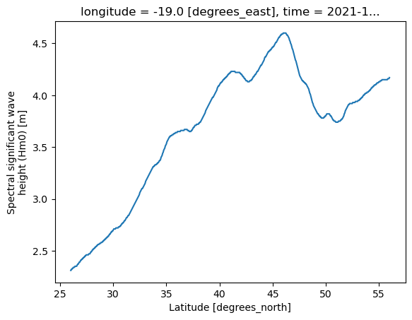

```python
VHM0.isel(time=-1,longitude=0).plot()
```

```python
#otra forma de seleccionar
VHM0[-1,:,0]
#Checkeamos qué eje es cada coordenada
VHM0.get_axis_num("longitude")
```

Podemos obtener los valores del data-array como un array de numpy utilizando el atributo `.values`

```python
#obtener los valores como un numpy array
print('Primeros 10 elementos de VHM0:\n ', VHM0[0,:,0].values[0:10],'\n')
print('Clase: ', type(VHM0[0,:,0].values))
```

```
Primeros 10 elementos de VHM0:
  [1.55      1.56      1.5699999 1.5699999 1.5799999 1.5899999 1.5999999
 1.61      1.62      1.62     ]

Clase:  <class 'numpy.ndarray'>
```

Más selecciones en el espacio de los índices...

```python
#Seleccionar un subconjunto utilizando el espacio de índices
subset= VHM0[0:10,0:10,0:10]

#Selección utilizando índices vectoriales
VHM0[[0,10],[0,1],[0,20]]
```

Otra forma de seleccionar es utilizando las etiquetas de los nombres de las coordenadas, este tipo de selección ocurre en el espacio de las etiquetas:

```python
#Selecciones en el espacio de etiquetas
#tiempo
VHM0.sel(time='1993-01-01T00:00:00.000000000')
#latitud
VHM0.sel(latitude=26)

#Selecciones en el espacio de etiquetas, otra forma:
#tiempo
VHM0.loc['1993-01-01T00:00:00.000000000', :, :]
#latitud
VHM0.loc[:, 26, :]

# Seleccionar un subconjunto de valores
subset_VHM0 = VHM0.sel(time=pd.date_range(datetime(2020,1,1) , datetime(2021,1,1), freq='1D'))
subset_VHM0

# rango de latitudes
subset_VHM0_lat = VHM0.sel(latitude=np.arange(26,29,1))
subset_VHM0_lat
```

```
<xarray.DataArray 'VHM0' (time: 254184, latitude: 3, longitude: 481)>
[366787512 values with dtype=float32]
Coordinates:
  * latitude   (latitude) float32 26.0 27.0 28.0
  * longitude  (longitude) float32 -19.0 -18.95 -18.9 -18.85 ... 4.9 4.95 5.0
  * time       (time) datetime64[ns] 1993-01-01 ... 2021-12-30T23:00:00
Attributes:
    units:             m
    standard_name:     sea_surface_wave_significant_height
    long_name:         Spectral significant wave height (Hm0)
    type_of_analysis:  spectral analysis
    WMO_code:          100
    valid_min:         0
    valid_max:         3000
    _ChunkSizes:       [12, 301, 241]
```

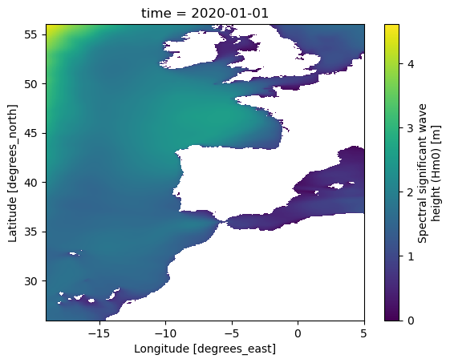

```python
VHM0.sel(time='2020-01-01T00:00:00.000000000').plot()
```

El método `sel` posee los argumentos `method` y `tolerance` que permiten la búsqueda de vecinos cercanos. Lo que nos permite hacer selecciones utilizar valores arbitrarios para las coordenadas.

```python
VHM0.sel(time=['2021-12-20T23:00:00'], method="nearest", tolerance='1H')
```

```python
VHM0.sel(time=['2021-12-20T23:00:00'], method="nearest", tolerance='1H').plot()
```

```python
VHM0.sel(time=['2021-12-20T23:00:00'], method="nearest",
         tolerance='1H').sel(longitude=slice(-11, 0), latitude=slice(45,55)).plot()
```

```python
VHM0.sel(latitude=[24,60], method="nearest", tolerance=5)
```

Podemos graficar también la serie temporal para la variación a lo largo de un año de la altura del oleaje en un punto.

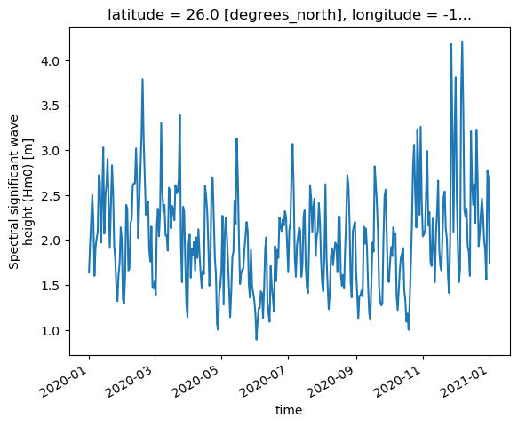

```python
subset_VHM0[:,0,0].plot()
```

# Operaciones con xarray

```python
print('Checkear si los valores se encuentran en una lista:','\n')
print(subset_VHM0[0,0:10,0].isin([1.55,1.63, 1.57,1.58]),'\n')

print('Resta:','\n')
print(subset_VHM0[0:2,0:2,0:2] -5,'\n')

print('Aplicar una función de numpy:','\n')
print(np.sin(subset_VHM0[0:2,0:2,0:2]),'\n')

print('Encontrar valores para una condición:','\n')
print(xr.where(subset_VHM0[0:2,0:2,0:2] > 0, "positive", "negative"),'\n')

print('Multiplicación matricial:','\n')
print(subset_VHM0[0:2,0:2,0:2] @ subset_VHM0[0:2,0:2,0:2],'\n')

print('Redondear valores:','\n')
print(subset_VHM0[0:2,0:2,0:2].round(1),'\n')

print('Encontrar NaNs:','\n')
print(subset_VHM0[0:2,0:2,0:2].isnull(),'\n')
```

## Interpolaciones

```python
subset_VHM0[0,0:10,0].latitude
```

```
<xarray.DataArray 'latitude' (latitude: 10)>
array([26.  , 26.05, 26.1 , 26.15, 26.2 , 26.25, 26.3 , 26.35, 26.4 , 26.45],
      dtype=float32)
Coordinates:
  * latitude   (latitude) float32 26.0 26.05 26.1 26.15 ... 26.35 26.4 26.45
    longitude  float32 -19.0
    time       datetime64[ns] 2020-01-01
Attributes:
    standard_name:        latitude
    long_name:            Latitude
    units:                degrees_north
    axis:                 Y
    unit_long:            Degrees North
    step:                 0.05f
    _CoordinateAxisType:  Lat
    _ChunkSizes:          601
```

```python
VHM0_int = subset_VHM0[0,0:10,0].interp(latitude=[26.04,26.17,26.22,26.34,26.44], method='linear')
```

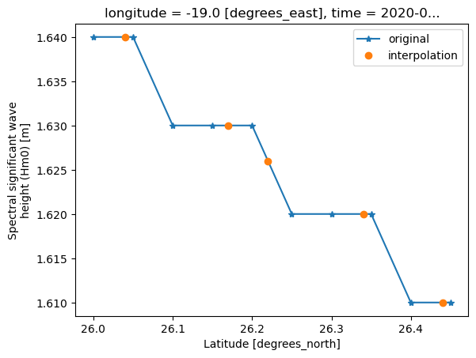

```python
subset_VHM0[0,0:10,0].plot(marker='*',label='nearest')
plt.plot(VHM0_int['latitude'],VHM0_int.values,'o')

plt.legend(['original','interpolation'])
```

## Rolling

En éste método, recorremos las coordenadas considerando una ''ventana'' que puede estar centrada o no en cada uno de los puntos con unas dimensiones dadas, y asignamos a cada punto el valor medio de los datos abarcados por la ventana.

```python
## Ventana temporal con un tamaño dado
VHM0_r1=VHM0[0:100,0,0].rolling(time=3, center=True).mean() #windows size equal 3
VHM0_r2=VHM0[0:100,0,0].rolling(time=10, center=True).mean()#windows size equal 10
```

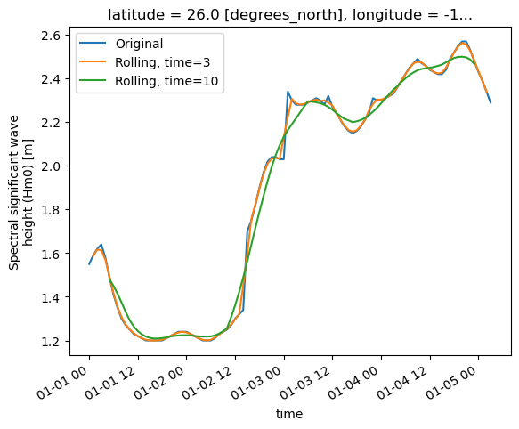

```python
VHM0[0:100,0,0].plot()
VHM0_r1.plot()
VHM0_r2.plot()
plt.legend(['Original', 'Rolling, time=3','Rolling, time=10'])
```

Podemos hacer un rolling en más dimensiones:

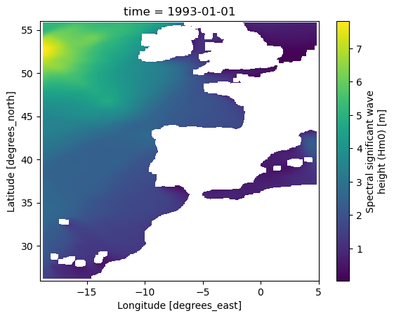

```python
VHM0[0,:,:].rolling(latitude=10, longitude=10, center=True).mean().plot()
```

## Group by

Este método agrupa los datos de acuerdo a diferentes criterios, en este caso por mes.

```python
group_by=subset_VHM0[:,0,0].groupby(subset_VHM0[:,0,0].time.dt.month)
group_by
```

```
DataArrayGroupBy, grouped over 'month'
12 groups with labels 1, 2, 3, 4, 5, 6, 7, 8, 9, 10, 11, 12.
```

```python
group_by
```

```
DataArrayGroupBy, grouped over 'month'
12 groups with labels 1, 2, 3, 4, 5, 6, 7, 8, 9, 10, 11, 12.
```

```python
for group_name, group_da in group_by:
    print('Grupo: ',group_name)
    print(group_da.values[0:10])
```

```
Grupo:  1
[1.64      1.9499999 2.23      2.5       2.21      1.5999999 1.92
 2.02      2.09      2.72     ]
Grupo:  2
[1.3399999 1.29      1.5799999 2.3899999 2.35      1.66      1.68
 2.19      2.23      2.61     ]
Grupo:  3
[1.54      1.39      2.1599998 2.35      2.04      2.33      3.3
 2.56      2.31      2.3899999]
Grupo:  4
[1.9599999 2.06      1.5799999 1.9       1.8299999 1.9799999 1.66
 2.03      1.8       2.12     ]
Grupo:  5
[1.67      2.27      1.28      2.05      2.25      2.04      1.76
 1.4499999 1.14      1.43     ]
Grupo:  6
[1.1899999 0.89      1.09      1.24      1.24      1.43      1.41
 1.13      1.4699999 1.91     ]
Grupo:  7
[1.64      2.11      2.19      2.73      3.07      2.57      1.8
 1.5899999 1.9399999 2.04     ]
Grupo:  8
[1.52      1.43      1.8199999 2.62      1.81      1.49      1.23
 1.41      1.8199999 1.9      ]
Grupo:  9
[1.65      1.4       1.12      1.38      1.38      1.4399999 1.37
 2.1499999 1.9599999 2.1299999]
Grupo:  10
[1.53      1.74      1.92      1.8199999 2.1399999 2.07      2.07
 1.38      1.22      1.4399999]
Grupo:  11
[2.04      2.06      2.11      2.53      2.99      2.1599998 2.31
 1.76      1.7099999 2.24     ]
Grupo:  12
[3.81      2.51      1.9399999 1.53      1.67      3.6499999 4.21
 3.4399998 2.33      2.26     ]
```

## Agregaciones

El método `Group by` admite múltiples operaciones de agregación.

```python
#group_by.mean(dim='time')
#group_by.min(dim='time')
#group_by.max(dim='time')
group_by.std(dim='time')
```

```
<xarray.DataArray 'VHM0' (month: 12)>
array([0.43052614, 0.59213173, 0.50029004, 0.41812557, 0.4349775 ,
       0.42850074, 0.38496485, 0.38696074, 0.47952336, 0.61266124,
       0.57467878, 0.66758436])
Coordinates:
    latitude   float32 26.0
    longitude  float32 -19.0
  * month      (month) int64 1 2 3 4 5 6 7 8 9 10 11 12
```

```python
#otra forma es utilizando el método .map
group_by.map(np.mean)
```

```
<xarray.DataArray 'VHM0' (month: 12)>
array([2.151875 , 2.2772415, 2.2125802, 1.859    , 1.8454839, 1.6306664,
       2.0838706, 1.8696775, 1.768    , 1.9454838, 2.221    , 2.4538708],
      dtype=float32)
Coordinates:
    latitude   float32 26.0
    longitude  float32 -19.0
  * month      (month) int64 1 2 3 4 5 6 7 8 9 10 11 12
```

```python
#podemos definir nuestra propia función y utilizar el método apply en lugar de map
def time_mean(a):
    return a.mean(dim='time')

group_by.apply(time_mean)
```

```
<xarray.DataArray 'VHM0' (month: 12)>
array([2.151875 , 2.2772415, 2.2125802, 1.859    , 1.8454839, 1.6306664,
       2.0838706, 1.8696775, 1.768    , 1.9454838, 2.221    , 2.4538708],
      dtype=float32)
Coordinates:
    latitude   float32 26.0
    longitude  float32 -19.0
  * month      (month) int64 1 2 3 4 5 6 7 8 9 10 11 12
```

## Resampleo

```python
VHM0_resample = VHM0[0:1000,:,:].resample(time='48H').mean(dim='time')
```

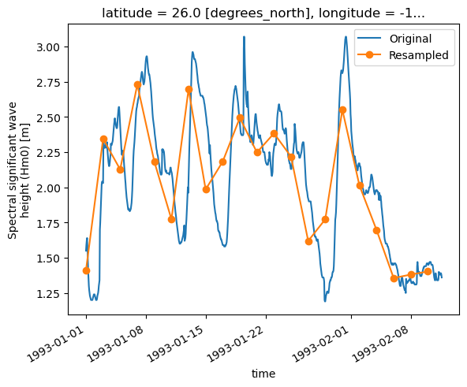

```python
VHM0[0:1000,0,0].plot()
VHM0_resample[:,0,0].plot(marker='o')
plt.legend(['Original','Resampled'])
```

# Generar un datarray

```python
#coordenadas
long = np.arange(26,50,1)
lat = np.arange(-15,5,1)
times = pd.date_range("2000-01-01", periods=4)

#variables
data = np.random.rand(len(times),len(long),len(lat))

height = xr.DataArray(data, coords=[times, long, lat], dims=["time", "longitude", "latitude"])

height
```

```
<xarray.DataArray (time: 4, longitude: 24, latitude: 20)>
array([[[0.42331636, 0.037309  , 0.21390054, ..., 0.80470857,
         0.18946967, 0.49523373],
        [0.48380064, 0.36490765, 0.72245696, ..., 0.4039939 ,
         0.14019459, 0.80345062],
        [0.62024964, 0.03362098, 0.66492852, ..., 0.94495732,
         0.43520784, 0.95072244],
        ...,
        [0.94109447, 0.5941955 , 0.373899  , ..., 0.217392  ,
         0.56907405, 0.87908352],
        [0.80263479, 0.71603436, 0.36253801, ..., 0.36886301,
         0.1662718 , 0.65296304],
        [0.12125788, 0.22944831, 0.08645069, ..., 0.13855975,
         0.10948634, 0.77453362]],

       [[0.40890843, 0.12349221, 0.92173514, ..., 0.84741802,
         0.82549322, 0.73808954],
        [0.70953177, 0.8247662 , 0.81245915, ..., 0.22358778,
         0.78312564, 0.70094865],
        [0.58852805, 0.46300594, 0.18672746, ..., 0.37875806,
         0.42861218, 0.25495702],
...
        [0.85626765, 0.98534765, 0.3273365 , ..., 0.29123433,
         0.14730583, 0.94857982],
        [0.71520433, 0.0355521 , 0.32355072, ..., 0.19565509,
         0.07249902, 0.49593296],
        [0.39950332, 0.61708015, 0.9497945 , ..., 0.37845323,
         0.39293994, 0.33264408]],

       [[0.73500842, 0.66123981, 0.90536109, ..., 0.44277037,
         0.64451076, 0.26516261],
        [0.15232527, 0.82011768, 0.11452989, ..., 0.92579631,
         0.87235034, 0.99849444],
        [0.96682181, 0.35769214, 0.20262882, ..., 0.21448671,
         0.03395118, 0.66295937],
        ...,
        [0.60130162, 0.65413953, 0.85914808, ..., 0.88662848,
         0.27638124, 0.14380476],
        [0.92960567, 0.31929206, 0.68738711, ..., 0.79611759,
         0.76090985, 0.38610898],
        [0.32816227, 0.90297894, 0.92842279, ..., 0.20096166,
         0.39291599, 0.46451506]]])
Coordinates:
  * time       (time) datetime64[ns] 2000-01-01 2000-01-02 2000-01-03 2000-01-04
  * longitude  (longitude) int32 26 27 28 29 30 31 32 ... 43 44 45 46 47 48 49
  * latitude   (latitude) int32 -15 -14 -13 -12 -11 -10 -9 ... -2 -1 0 1 2 3 4
```

```python
#agregar atributos
height.name = "height"

height.attrs["units"] = "meters"
height.attrs["more"] = "more information"

height
```

```
<xarray.DataArray 'height' (time: 4, longitude: 24, latitude: 20)>
array([[[0.42331636, 0.037309  , 0.21390054, ..., 0.80470857,
         0.18946967, 0.49523373],
        [0.48380064, 0.36490765, 0.72245696, ..., 0.4039939 ,
         0.14019459, 0.80345062],
        [0.62024964, 0.03362098, 0.66492852, ..., 0.94495732,
         0.43520784, 0.95072244],
        ...,
        [0.94109447, 0.5941955 , 0.373899  , ..., 0.217392  ,
         0.56907405, 0.87908352],
        [0.80263479, 0.71603436, 0.36253801, ..., 0.36886301,
         0.1662718 , 0.65296304],
        [0.12125788, 0.22944831, 0.08645069, ..., 0.13855975,
         0.10948634, 0.77453362]],

       [[0.40890843, 0.12349221, 0.92173514, ..., 0.84741802,
         0.82549322, 0.73808954],
        [0.70953177, 0.8247662 , 0.81245915, ..., 0.22358778,
         0.78312564, 0.70094865],
        [0.58852805, 0.46300594, 0.18672746, ..., 0.37875806,
         0.42861218, 0.25495702],
...
        [0.85626765, 0.98534765, 0.3273365 , ..., 0.29123433,
         0.14730583, 0.94857982],
        [0.71520433, 0.0355521 , 0.32355072, ..., 0.19565509,
         0.07249902, 0.49593296],
        [0.39950332, 0.61708015, 0.9497945 , ..., 0.37845323,
         0.39293994, 0.33264408]],

       [[0.73500842, 0.66123981, 0.90536109, ..., 0.44277037,
         0.64451076, 0.26516261],
        [0.15232527, 0.82011768, 0.11452989, ..., 0.92579631,
         0.87235034, 0.99849444],
        [0.96682181, 0.35769214, 0.20262882, ..., 0.21448671,
         0.03395118, 0.66295937],
        ...,
        [0.60130162, 0.65413953, 0.85914808, ..., 0.88662848,
         0.27638124, 0.14380476],
        [0.92960567, 0.31929206, 0.68738711, ..., 0.79611759,
         0.76090985, 0.38610898],
        [0.32816227, 0.90297894, 0.92842279, ..., 0.20096166,
         0.39291599, 0.46451506]]])
Coordinates:
  * time       (time) datetime64[ns] 2000-01-01 2000-01-02 2000-01-03 2000-01-04
  * longitude  (longitude) int32 26 27 28 29 30 31 32 ... 43 44 45 46 47 48 49
  * latitude   (latitude) int32 -15 -14 -13 -12 -11 -10 -9 ... -2 -1 0 1 2 3 4
Attributes:
    units:    meters
    more:     more information
```

```python
#otras formas
#xr.DataArray(data, coords=[("time", times), ("longitude", long), ("latitude", lat)])
```

```python
# xr.DataArray(
#     data,
#     coords={
#         "time": times,
#         "longitude": long,
#         "latitude": lat,
#     },
#     dims=["time", "longitude", "latitude"],
# )
```

```python
# xr.DataArray(
#     data,
#     coords={
#         "time": times,
#         "longitude": long,
#         "latitude": lat,
#         "ranking": (("time", "longitude", "latitude"),
#                     np.arange(len(times)*len(long)*len(lat)).reshape(len(times),
#                                                                      len(long), len(lat))),
#     },
#     dims=["time", "longitude", "latitude"],
# )
```

# Generar un DataSet

```python
np.random.seed(0)
temperature = 15 + 8 * np.random.randn(2, 2, 3)
precipitation = 10 * np.random.rand(2, 2, 3)
lon = [[-99.83, -99.32], [-99.79, -99.23]]
lat = [[42.25, 42.21], [42.63, 42.59]]
time = pd.date_range("2014-09-06", periods=3)
reference_time = pd.Timestamp("2014-09-05")
```

```python
ds2 = xr.Dataset(
    data_vars=dict(
        temperature=(["x", "y", "time"], temperature),
        precipitation=(["x", "y", "time"], precipitation),
    ),
    coords=dict(
        lon=(["x", "y"], lon),
        lat=(["x", "y"], lat),
        time=time,
        reference_time=reference_time,
    ),
    attrs=dict(description="Weather related data."),
)
ds2
```

```
<xarray.Dataset>
Dimensions:         (x: 2, y: 2, time: 3)
Coordinates:
    lon             (x, y) float64 -99.83 -99.32 -99.79 -99.23
    lat             (x, y) float64 42.25 42.21 42.63 42.59
  * time            (time) datetime64[ns] 2014-09-06 2014-09-07 2014-09-08
    reference_time  datetime64[ns] 2014-09-05
Dimensions without coordinates: x, y
Data variables:
    temperature     (x, y, time) float64 29.11 18.2 22.83 ... 18.28 16.15 26.63
    precipitation   (x, y, time) float64 5.68 9.256 0.7104 ... 7.992 4.615 7.805
Attributes:
    description:  Weather related data.
```

# Escribir un netcdf

```python
#es necesario convertir primero el datarray en dataset
height.to_dataset
```

```
<bound method DataArray.to_dataset of <xarray.DataArray 'height' (time: 4, longitude: 24, latitude: 20)>
array([[[0.42331636, 0.037309  , 0.21390054, ..., 0.80470857,
         0.18946967, 0.49523373],
        [0.48380064, 0.36490765, 0.72245696, ..., 0.4039939 ,
         0.14019459, 0.80345062],
        [0.62024964, 0.03362098, 0.66492852, ..., 0.94495732,
         0.43520784, 0.95072244],
        ...,
        [0.94109447, 0.5941955 , 0.373899  , ..., 0.217392  ,
         0.56907405, 0.87908352],
        [0.80263479, 0.71603436, 0.36253801, ..., 0.36886301,
         0.1662718 , 0.65296304],
        [0.12125788, 0.22944831, 0.08645069, ..., 0.13855975,
         0.10948634, 0.77453362]],

       [[0.40890843, 0.12349221, 0.92173514, ..., 0.84741802,
         0.82549322, 0.73808954],
        [0.70953177, 0.8247662 , 0.81245915, ..., 0.22358778,
         0.78312564, 0.70094865],
        [0.58852805, 0.46300594, 0.18672746, ..., 0.37875806,
         0.42861218, 0.25495702],
...
        [0.85626765, 0.98534765, 0.3273365 , ..., 0.29123433,
         0.14730583, 0.94857982],
        [0.71520433, 0.0355521 , 0.32355072, ..., 0.19565509,
         0.07249902, 0.49593296],
        [0.39950332, 0.61708015, 0.9497945 , ..., 0.37845323,
         0.39293994, 0.33264408]],

       [[0.73500842, 0.66123981, 0.90536109, ..., 0.44277037,
         0.64451076, 0.26516261],
        [0.15232527, 0.82011768, 0.11452989, ..., 0.92579631,
         0.87235034, 0.99849444],
        [0.96682181, 0.35769214, 0.20262882, ..., 0.21448671,
         0.03395118, 0.66295937],
        ...,
        [0.60130162, 0.65413953, 0.85914808, ..., 0.88662848,
         0.27638124, 0.14380476],
        [0.92960567, 0.31929206, 0.68738711, ..., 0.79611759,
         0.76090985, 0.38610898],
        [0.32816227, 0.90297894, 0.92842279, ..., 0.20096166,
         0.39291599, 0.46451506]]])
Coordinates:
  * time       (time) datetime64[ns] 2000-01-01 2000-01-02 2000-01-03 2000-01-04
  * longitude  (longitude) int32 26 27 28 29 30 31 32 ... 43 44 45 46 47 48 49
  * latitude   (latitude) int32 -15 -14 -13 -12 -11 -10 -9 ... -2 -1 0 1 2 3 4
Attributes:
    units:    meters
    more:     more information>
```

```python
# Write netcdf
height.to_netcdf("height.nc")
```

Aparición de NaN's: no hay un valor asignado de la variable en cuestion para cada posible combinacion de coordenadas. Esto sucede cuando se pasa de una tabla a cubo.

# Exportar datos en formato tabla

Podemos transformar el dataset a un dataframe:

```python
#se puede convertir el dataset a una serie de pandas
df=height.to_dataframe()
df
```

| time | longitude | latitude | height |
| --- | --- | --- | --- |
| 2000-01-01 | 26 | -15 | 0.423316 |
|  |  | -14 | 0.037309 |
|  |  | -13 | 0.213901 |
|  |  | -12 | 0.011739 |
|  |  | -11 | 0.256225 |
| ... | ... | ... | ... |
| 2000-01-04 | 49 | 0 | 0.937455 |
|  |  | 1 | 0.045707 |
|  |  | 2 | 0.200962 |
|  |  | 3 | 0.392916 |
|  |  | 4 | 0.464515 |

1920 rows × 1 columns

Una vez creado el dataframe, podemos exportar los datos a diferentes formatos:

```python
# Export to other formats...
df.to_csv("VHM0.csv")
df.to_html("VHM0.html")

# Check arguments in libraries docuemntation for more options...
df.to_json("VHM0.json", orient="records", indent=4)
```